# Association Rules Learning

Pretty simple concept. . . .people that buy also buy. . . . .

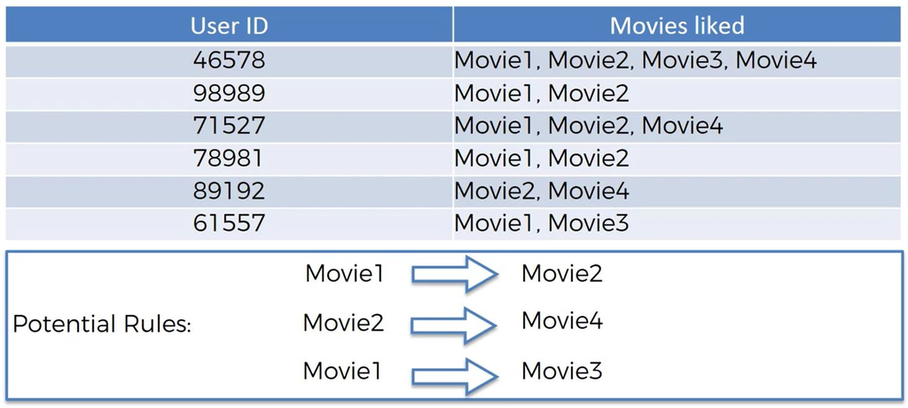

Apriori Algorithm consists of 3 parts:

> apriori - previous knowledge
- Support: number of people that picked something / all users
- Confidence: number of x and y / x

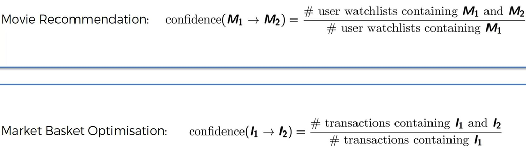

- Lift: confidence / support

Process:

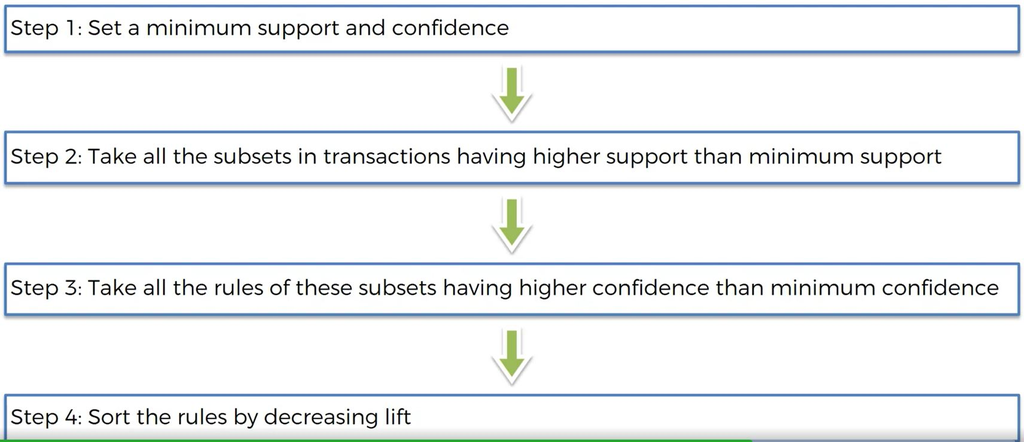

> Apriori is a basic example - recommendation engines are more sophisticated

```r
# Data Preprocessing
#We execute the read.csv onlt to see the data.  Not needed for read.transactions
dataset = read.csv('../data/Market_Basket_Optimisation.csv', header = FALSE)
head(dataset)
```

```
##               V1        V2         V3               V4           V5
## 1         shrimp   almonds    avocado   vegetables mix green grapes
## 2        burgers meatballs       eggs
## 3        chutney
## 4         turkey   avocado
## 5  mineral water      milk energy bar whole wheat rice    green tea
## 6 low fat yogurt
##                 V6   V7             V8           V9          V10
## 1 whole weat flour yams cottage cheese energy drink tomato juice
## 2
## 3
## 4
## 5
## 6
##              V11       V12   V13   V14           V15    V16
## 1 low fat yogurt green tea honey salad mineral water salmon
## 2
## 3
## 4
## 5
## 6
##                 V17             V18     V19       V20
## 1 antioxydant juice frozen smoothie spinach olive oil
## 2
## 3
## 4
## 5
## 6
```

```r
#Now make a sparse matrix - each product will have its own column
dataset = read.transactions('../data/Market_Basket_Optimisation.csv', sep = ',', rm.duplicates = TRUE)
```

```
## distribution of transactions with duplicates:
## 1
## 5
```

```r
#Line above returns some informnation.  Interpret as 5 transactions with 1 duplicate
summary(dataset)
```

```
## transactions as itemMatrix in sparse format with
##  7501 rows (elements/itemsets/transactions) and
##  119 columns (items) and a density of 0.03288973
##
## most frequent items:
## mineral water          eggs     spaghetti  french fries     chocolate
##          1788          1348          1306          1282          1229
##       (Other)
##         22405
##
## element (itemset/transaction) length distribution:
## sizes
##    1    2    3    4    5    6    7    8    9   10   11   12   13   14   15
## 1754 1358 1044  816  667  493  391  324  259  139  102   67   40   22   17
##   16   18   19   20
##    4    1    2    1
##
##    Min. 1st Qu.  Median    Mean 3rd Qu.    Max.
##   1.000   2.000   3.000   3.914   5.000  20.000
##
## includes extended item information - examples:
##              labels
## 1           almonds
## 2 antioxydant juice
## 3         asparagus
```

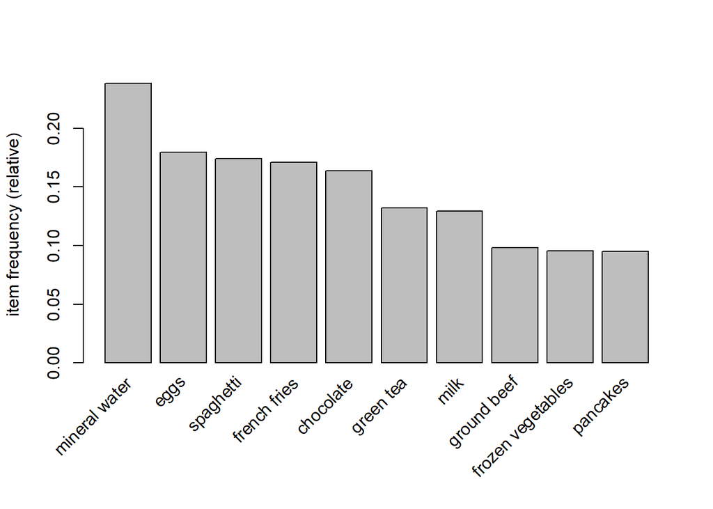

```r
itemFrequencyPlot(dataset, topN = 10)
```

```r
# Training Apriori on the dataset
# support and confidence are based on specific circumstances - no rules to follow
# We are going to evalaute the products that are purchased 3 times/day only (iterative process).  The dataset contains a weeks worth of purchase data.  Therefore support = (3x7)/7500
# Confidence depnds on business rules.  Start with default then iterate (.8 is very high)
rules = apriori(data = dataset, parameter = list(support = 0.003, confidence = 0.8))
```

```
## Apriori
##
## Parameter specification:
##  confidence minval smax arem  aval originalSupport maxtime support minlen
##         0.8    0.1    1 none FALSE            TRUE       5   0.003      1
##  maxlen target   ext
##      10  rules FALSE
##
## Algorithmic control:
##  filter tree heap memopt load sort verbose
##     0.1 TRUE TRUE  FALSE TRUE    2    TRUE
##
## Absolute minimum support count: 22
##
## set item appearances ...[0 item(s)] done [0.00s].
## set transactions ...[119 item(s), 7501 transaction(s)] done [0.00s].
## sorting and recoding items ... [115 item(s)] done [0.00s].
## creating transaction tree ... done [0.00s].
## checking subsets of size 1 2 3 4 5 done [0.02s].
## writing ... [0 rule(s)] done [0.00s].
## creating S4 object  ... done [0.00s].
```

```r
# 0 rules are produced by the code above.  Confidence is too high.  Being right 80% of the time!
rules = apriori(data = dataset, parameter = list(support = 0.003, confidence = 0.4))
```

```
## Apriori
##
## Parameter specification:
##  confidence minval smax arem  aval originalSupport maxtime support minlen
##         0.4    0.1    1 none FALSE            TRUE       5   0.003      1
##  maxlen target   ext
##      10  rules FALSE
##
## Algorithmic control:
##  filter tree heap memopt load sort verbose
##     0.1 TRUE TRUE  FALSE TRUE    2    TRUE
##
## Absolute minimum support count: 22
##
## set item appearances ...[0 item(s)] done [0.00s].
## set transactions ...[119 item(s), 7501 transaction(s)] done [0.00s].
## sorting and recoding items ... [115 item(s)] done [0.00s].
## creating transaction tree ... done [0.00s].
## checking subsets of size 1 2 3 4 5 done [0.00s].
## writing ... [281 rule(s)] done [0.00s].
## creating S4 object  ... done [0.00s].
```

```r
#Now 281 rules!

# Visualizing the results
inspect(sort(rules, by = 'lift')[1:10])
```

```
##      lhs                    rhs                     support confidence     lift
## [1]  {mineral water,
##       whole wheat pasta} => {olive oil}         0.003866151  0.4027778 6.115863
## [2]  {spaghetti,
##       tomato sauce}      => {ground beef}       0.003066258  0.4893617 4.980600
## [3]  {french fries,
##       herb & pepper}     => {ground beef}       0.003199573  0.4615385 4.697422
## [4]  {cereals,
##       spaghetti}         => {ground beef}       0.003066258  0.4600000 4.681764
## [5]  {frozen vegetables,
##       mineral water,
##       soup}              => {milk}              0.003066258  0.6052632 4.670863
## [6]  {chocolate,
##       herb & pepper}     => {ground beef}       0.003999467  0.4411765 4.490183
## [7]  {chocolate,
##       mineral water,
##       shrimp}            => {frozen vegetables} 0.003199573  0.4210526 4.417225
## [8]  {frozen vegetables,
##       mineral water,
##       olive oil}         => {milk}              0.003332889  0.5102041 3.937285
## [9]  {cereals,
##       ground beef}       => {spaghetti}         0.003066258  0.6764706 3.885303
## [10] {frozen vegetables,
##       soup}              => {milk}              0.003999467  0.5000000 3.858539
```

Some problems are suggested in the output. Example: [6] chocolate, herb & pepper suggests ground beef. Recall chocolate is one of the most purchased items so it shows up in baskets but does this make sense? This might suggest that the confidence it still too high. (We do not want to change the business rules that drive the support parameter.) Same potential problem with mineral water.

```r
rules = apriori(data = dataset, parameter = list(support = 0.003, confidence = 0.2))
```

```
## Apriori
##
## Parameter specification:
##  confidence minval smax arem  aval originalSupport maxtime support minlen
##         0.2    0.1    1 none FALSE            TRUE       5   0.003      1
##  maxlen target   ext
##      10  rules FALSE
##
## Algorithmic control:
##  filter tree heap memopt load sort verbose
##     0.1 TRUE TRUE  FALSE TRUE    2    TRUE
##
## Absolute minimum support count: 22
##
## set item appearances ...[0 item(s)] done [0.00s].
## set transactions ...[119 item(s), 7501 transaction(s)] done [0.02s].
## sorting and recoding items ... [115 item(s)] done [0.00s].
## creating transaction tree ... done [0.00s].
## checking subsets of size 1 2 3 4 5 done [0.01s].
## writing ... [1348 rule(s)] done [0.00s].
## creating S4 object  ... done [0.00s].
```

```r
inspect(sort(rules, by = 'lift')[1:10])
```

```
##      lhs                                       rhs             support
## [1]  {mineral water,whole wheat pasta}      => {olive oil}     0.003866151
## [2]  {frozen vegetables,milk,mineral water} => {soup}          0.003066258
## [3]  {fromage blanc}                        => {honey}         0.003332889
## [4]  {spaghetti,tomato sauce}               => {ground beef}   0.003066258
## [5]  {light cream}                          => {chicken}       0.004532729
## [6]  {pasta}                                => {escalope}      0.005865885
## [7]  {french fries,herb & pepper}           => {ground beef}   0.003199573
## [8]  {cereals,spaghetti}                    => {ground beef}   0.003066258
## [9]  {frozen vegetables,mineral water,soup} => {milk}          0.003066258
## [10] {french fries,ground beef}             => {herb & pepper} 0.003199573
##      confidence lift
## [1]  0.4027778  6.115863
## [2]  0.2771084  5.484407
## [3]  0.2450980  5.164271
## [4]  0.4893617  4.980600
## [5]  0.2905983  4.843951
## [6]  0.3728814  4.700812
## [7]  0.4615385  4.697422
## [8]  0.4600000  4.681764
## [9]  0.6052632  4.670863
## [10] 0.2307692  4.665768
```

Many more rules as expected - 1348. The rules appear to make more sense - most of them. Does cereal and spaghetti suggest ground beef with a 46% confidence?

Could try changing support. What happens if we change to products that 4 times/day? (support = (4 x 7)/7500 = 0.00373)

```r
rules = apriori(data = dataset, parameter = list(support = 0.004, confidence = 0.2))
```

```
## Apriori
##
## Parameter specification:
##  confidence minval smax arem  aval originalSupport maxtime support minlen
##         0.2    0.1    1 none FALSE            TRUE       5   0.004      1
##  maxlen target   ext
##      10  rules FALSE
##
## Algorithmic control:
##  filter tree heap memopt load sort verbose
##     0.1 TRUE TRUE  FALSE TRUE    2    TRUE
##
## Absolute minimum support count: 30
##
## set item appearances ...[0 item(s)] done [0.00s].
## set transactions ...[119 item(s), 7501 transaction(s)] done [0.00s].
## sorting and recoding items ... [114 item(s)] done [0.00s].
## creating transaction tree ... done [0.00s].
## checking subsets of size 1 2 3 4 done [0.00s].
## writing ... [811 rule(s)] done [0.00s].
## creating S4 object  ... done [0.00s].
```

```r
inspect(sort(rules, by = 'lift')[1:10])
```

```
##      lhs                       rhs                 support confidence     lift
## [1]  {light cream}          => {chicken}       0.004532729  0.2905983 4.843951
## [2]  {pasta}                => {escalope}      0.005865885  0.3728814 4.700812
## [3]  {pasta}                => {shrimp}        0.005065991  0.3220339 4.506672
## [4]  {eggs,
##       ground beef}          => {herb & pepper} 0.004132782  0.2066667 4.178455
## [5]  {whole wheat pasta}    => {olive oil}     0.007998933  0.2714932 4.122410
## [6]  {herb & pepper,
##       spaghetti}            => {ground beef}   0.006399147  0.3934426 4.004360
## [7]  {herb & pepper,
##       mineral water}        => {ground beef}   0.006665778  0.3906250 3.975683
## [8]  {tomato sauce}         => {ground beef}   0.005332622  0.3773585 3.840659
## [9]  {mushroom cream sauce} => {escalope}      0.005732569  0.3006993 3.790833
## [10] {frozen vegetables,
##       mineral water,
##       spaghetti}            => {ground beef}   0.004399413  0.3666667 3.731841
```

811 rules now because of the increased support. Rules look valid. Now business owner could rearrange product placements to improve sales.